# **La matrice dei dati**

# Una matrice $7\times 2$

Si costruisca la seguente matrice di dati $X$ di dimensione $n=7$ e $p=2$:

$$\underset{7\times 2}{X} =\left[
\begin{array}{cc}
3 & 5\\
4 & 5.5\\
2 & 4\\
6 & 7\\
8 & 10\\
2 & 5\\
5 & 7.5\\
\end{array}\right]$$

```r
rm(list=ls()) # pulizia del workspace
X <- matrix(
  c(3,4,2,6,8,2,5,
    5,5.5,4,7,10,5,7.5),
  nrow=7,ncol=2,
  byrow=FALSE)
n <- nrow(X)
p <- ncol(X)
colnames(X)<-c("x1","x2")
rownames(X)<-paste("u",1:n, sep="")
X
```

```
   x1   x2
u1  3  5.0
u2  4  5.5
u3  2  4.0
u4  6  7.0
u5  8 10.0
u6  2  5.0
u7  5  7.5
```

Per ottenere la matrice trasposta

```r
t(X)
```

```
   u1  u2 u3 u4 u5 u6  u7
x1  3 4.0  2  6  8  2 5.0
x2  5 5.5  4  7 10  5 7.5
```

Per calcolare le statistiche di sintesi per le due variabili (Min, Max, Primo e Terzo quartile, Mediana e Media):

```r
summary(X)
```

```
       x1              x2
 Min.   :2.000   Min.   : 4.000
 1st Qu.:2.500   1st Qu.: 5.000
 Median :4.000   Median : 5.500
 Mean   :4.286   Mean   : 6.286
 3rd Qu.:5.500   3rd Qu.: 7.250
 Max.   :8.000   Max.   :10.000
```

Per calcolare la media e varianza per la prima variabile:

```r
mean(X[,1])
```

```
[1] 4.285714
```

```r
((n-1)/n) * var(X[,1])
```

```
[1] 4.204082
```

Perchè moltiplichiamo la varianza per $(n-1)/n$? Guardare l’help: `?var`

Per calcolare il vettore delle medie:

```r
apply(X,MARGIN=2,FUN="mean")
```

```
      x1       x2
4.285714 6.285714
```

Per calcolare la matrice di varianze/covarianze $S$

```r
S = ((n-1)/n)*var(X)
S
```

```
         x1       x2
x1 4.204082 3.704082
x2 3.704082 3.561224
```

Per calcolare la matrice di correlazione $R$

```r
R = cor(X)
R
```

```
          x1        x2
x1 1.0000000 0.9572939
x2 0.9572939 1.0000000
```

Perchè in questo caso non moltiplichiamo per $(n-1)/n$?

Per costruire il diagramma di dispersione:

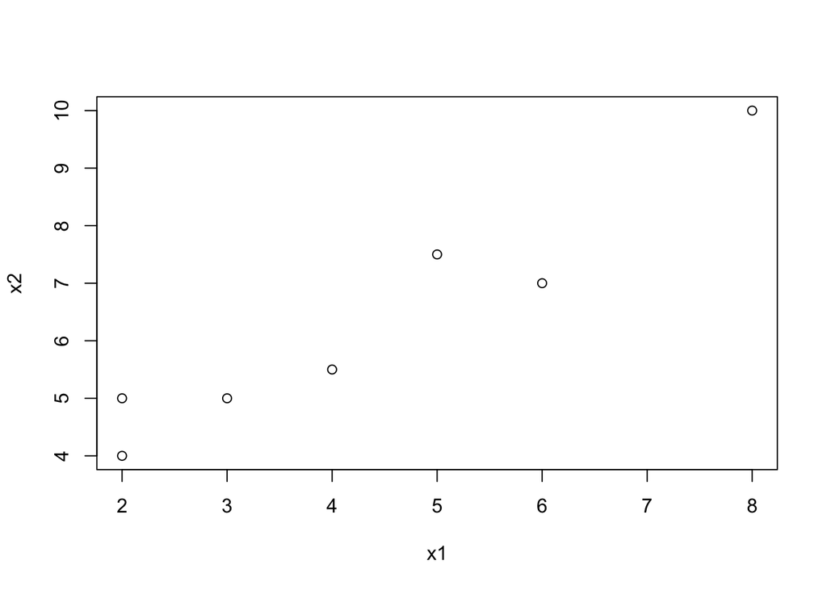

```r
plot(X)
```

Per cambiare l’ordine dei valori della variabile $x_1$ in maniera causale (permutazione), si può utilizzare il comando `sample()`. Per riproducibilità dei risultati, impostare all’inizio il seme generatore dei numeri casuali `set.seed(123)`.

```r
set.seed(123)
X[,"x1"] <- sample(X[,"x1"])
X
```

```
   x1   x2
u1  2  5.0
u2  8  5.5
u3  5  4.0
u4  6  7.0
u5  2 10.0
u6  3  5.0
u7  4  7.5
```

Se calcoliamo le statistiche di sintesi, la matrice di varianze/covarianze e di correlazione, e costruiamo il diagramma di dispersione, notiamo che le due distribuzioni marginali sono le stesse, ma la covarianza $s_{12}$ e il coefficiente di correlazione $r_{12}$ cambiano.

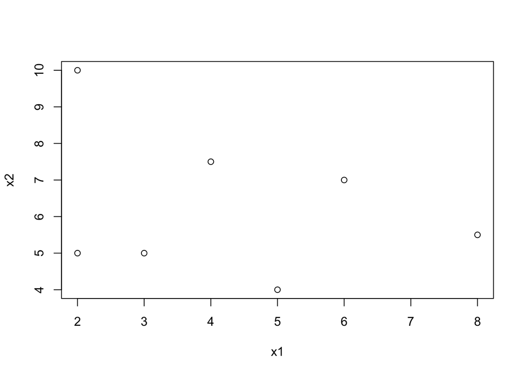

```r
plot(X)
```

```r
summary(X)
```

```
       x1              x2
 Min.   :2.000   Min.   : 4.000
 1st Qu.:2.500   1st Qu.: 5.000
 Median :4.000   Median : 5.500
 Mean   :4.286   Mean   : 6.286
 3rd Qu.:5.500   3rd Qu.: 7.250
 Max.   :8.000   Max.   :10.000
```

```r
((n-1)/n)*var(X)
```

```
          x1        x2
x1  4.204082 -1.081633
x2 -1.081633  3.561224
```

```r
cor(X)
```

```
           x1         x2
x1  1.0000000 -0.2795404
x2 -0.2795404  1.0000000
```

Quindi dalle due distribuzioni marginali non si può ricavare alcuna informazione sulla correlazione tra le due variabili $x_1$ e $x_2$.

# Correlazione lineare

Si consideri la seguente relazione quadratica tra le variabili $x_1$ e $x_2$:

$$\begin{aligned}
x_{1i} &= -1 + 2\frac{(i-1)}{(n-1)}\\
x_{2i} & = x_{1i}^2, \quad i=1,\ldots,n
\end{aligned}$$

Generare i dati come descritto sopra per $n=20$, costruire il diagramma di dispersione e calcolare la matrice di correlazione, e commentare i risultati ottenuti.

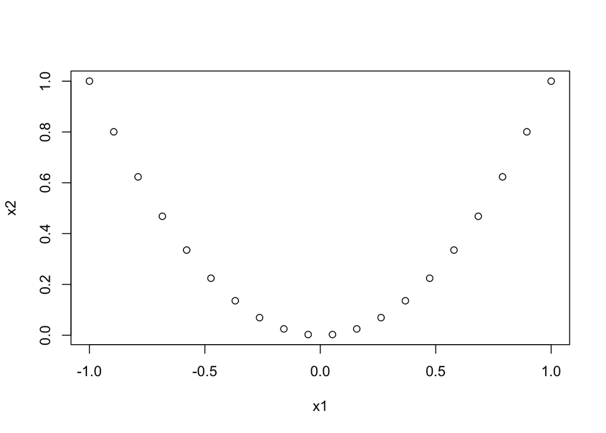

```r
n <- 20
x1 <- -1 + 2* ((1:n) -1 )/(n-1)
x2 <- x1^2
X <- cbind(x1,x2)
plot(x1,x2)
```

```r
cor(X)
```

```
             x1           x2
x1  1.00000e+00 -8.77515e-17
x2 -8.77515e-17  1.00000e+00
```

```r
round(cor(X),1) # arrotondo al primo decimale
```

```
   x1 x2
x1  1  0
x2  0  1
```

Come si vede, sebbene ci sia una dipendenza perfettamente quadratica tra le variabili $x_1$ e $x_2$, il coefficiente di correlazione $r_{12}\approx 0$, perchè misura solo la dipendenza lineare (ovvero, la correlazione) tra le due variabili

# Dati Animals

Caricare il data set `Animals`, presente nella libreria `MASS`, che si carica R con il comando `library("MASS")`:

```r
rm(list=ls())
library("MASS")
data(Animals)
?Animals
```

Dalla descrizione ottenuta con il comando `?Animals`, vediamo che si tratta di *Average brain and body weights for 28 species of land animals*.

E’ un data.frame con $n=28$ osservazioni misurate su $p=2$ variabili:

- `body` body weight in kg.
- `brain` brain weight in g.

```r
row.names(Animals)
```

```
 [1] "Mountain beaver"  "Cow"              "Grey wolf"        "Goat"             "Guinea pig"       "Dipliodocus"      "Asian elephant"   "Donkey"           "Horse"            "Potar monkey"     "Cat"
[12] "Giraffe"          "Gorilla"          "Human"            "African elephant" "Triceratops"      "Rhesus monkey"    "Kangaroo"         "Golden hamster"   "Mouse"            "Rabbit"           "Sheep"
[23] "Jaguar"           "Chimpanzee"       "Rat"              "Brachiosaurus"    "Mole"             "Pig"
```

Notare che sono presenti alcune specie estinte, come il Brachiosaurus, il Triceratops e il Dipliodocus.

1. Si verifichi graficamente la presenza di valori anomali per la variabile `brain`, utilizzando il *boxplot*, e commentare:

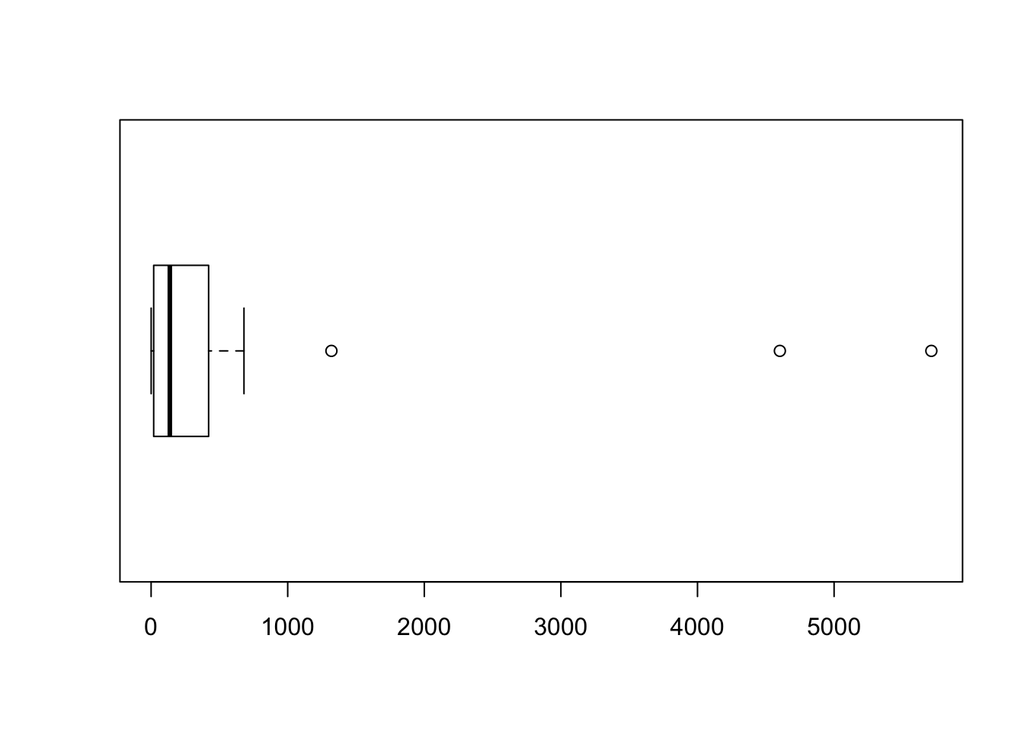

```r
with(Animals,
boxplot(brain, horizontal=TRUE)
)
```

Per la variabile `brain`, il *boxplot* identifica 3 valori anomali (evidenziandoli con $\circ$), perchè risultano superiori al baffo di destra.

2. Ricavare i valori corrispondenti al baffo sinistro e al baffo destro del *boxplot* utilizzando il comando boxplot.stats():

```r
boxplot.stats(Animals$brain)
```

```
$stats
[1]   0.40  18.85 137.00 421.00 680.00

$n
[1] 28

$conf
[1]  16.92125 257.07875

$out
[1] 4603 1320 5712
```

```r
baffo.sx <- boxplot.stats(Animals$brain)$stats[1]
baffo.sx
```

```
[1] 0.4
```

```r
baffo.dx <- boxplot.stats(Animals$brain)$stats[5]
baffo.dx
```

```
[1] 680
```

3. Ricavare i nomi delle specie corrispondenti agli *outliers*:

```r
outs <- boxplot.stats(Animals$brain)$out
outsTRUE <- Animals$brain %in% outs # restituisce un vettore logico
outsTRUE
```

```
 [1] FALSE FALSE FALSE FALSE FALSE FALSE  TRUE FALSE FALSE FALSE FALSE FALSE FALSE  TRUE  TRUE FALSE FALSE FALSE FALSE FALSE FALSE FALSE FALSE FALSE FALSE FALSE FALSE FALSE
```

```r
which.outs <- which(outsTRUE) # indici delle osservazioni anomale
which.outs
```

```
[1]  7 14 15
```

```r
rownames(Animals)[which.outs]
```

```
[1] "Asian elephant"   "Human"            "African elephant"
```

4. Costruire il diagramma di dispersione del peso del cervello in funzione del peso del corpo, calcolare la matrice di correlazione, e commentare il risultato ottenuto:

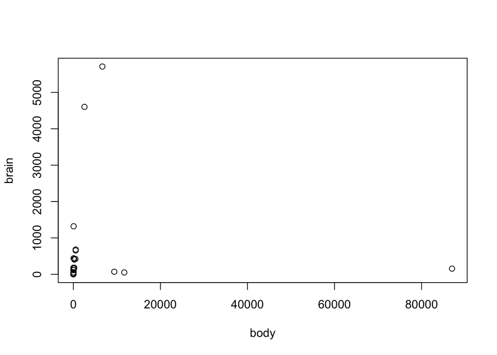

```r
plot(brain~body, Animals)
```

```r
cor(Animals)
```

```
              body        brain
body   1.000000000 -0.005341163
brain -0.005341163  1.000000000
```

La correlazione è quasi nulla, e quindi c’è poca dipendenza lineare tra il peso del cervello e il peso del corpo delle specie considerate.

5. Trasformare entrambe le variabili con la trasformazione logaritmica (che è una trasformazione non lineare), costruire il diagramma di dispersione e calcolare la matrice di correlazione, commentando i risultati ottenuti.

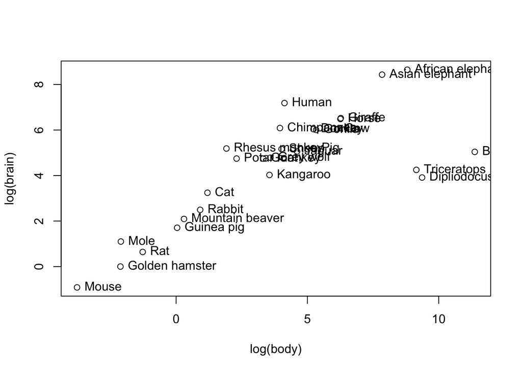

```r
plot(log(brain)~log(body), Animals)
with(Animals,
     text(log(brain)~log(body), labels = row.names(Animals), pos=4)
     )
```

```r
cor(log(Animals))
```

```
           body     brain
body  1.0000000 0.7794935
brain 0.7794935 1.0000000
```

Vediamo che ora è presente una sostanziale correlazione tra il logaritmo del peso del cervello e il logaritmo del peso del corpo. Questo esempio dimostra inoltre che la matrice di correlazione non è invariante rispetto a trasformazioni non lineari.

Notiamo però che ci sono 3 osservazioni che non si comportano come le altre (le specie estinte). Si tratta forse di valori anomali (*outliers*)? Potrebbe trattarsi di *outliers* bivariati, perchè non riusciamo ad identificare queste osservazioni anomale con l’utilizzo dei *boxplot*.

6. Costruire il `bagplot` per verificare se si tratta effettivamente di *outliers* bivariati, e ricavare i valori di queste osservazioni anomale.

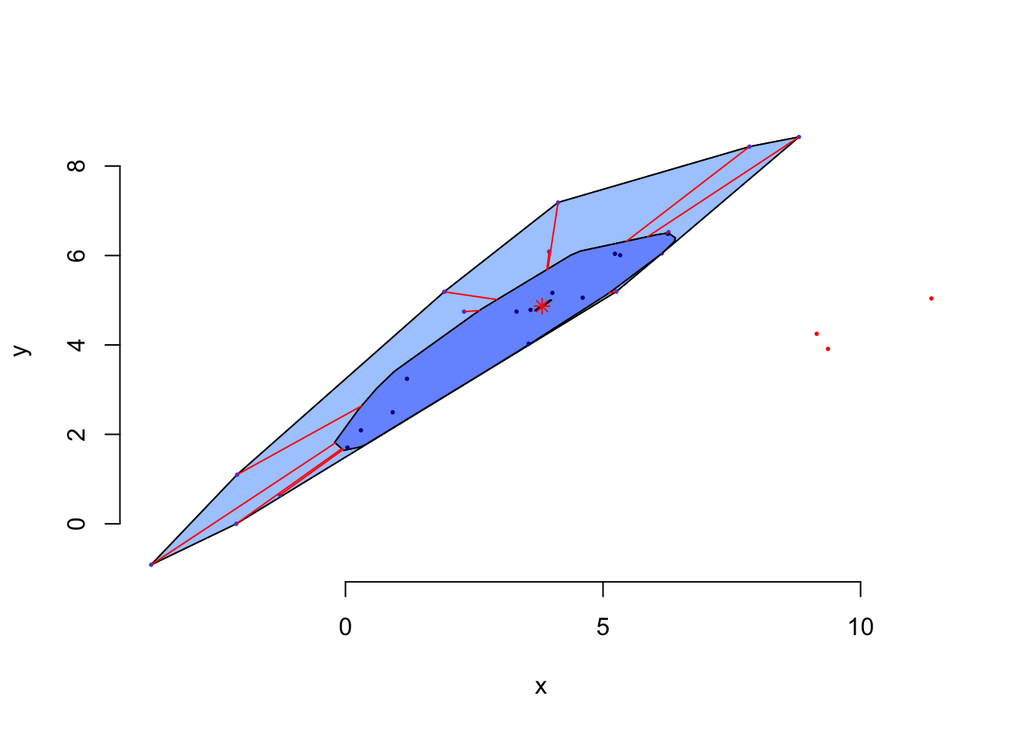

```r
library(aplpack) # bagplot richiede l'installazione del pacchetto aplpack
bag <- bagplot(log(Animals))
```

```r
# per ricavare i valori anomali del bagplot
bag$pxy.outlier
```

```
             x        y
[1,]  9.367344 3.912023
[2,]  9.148465 4.248495
[3,] 11.373663 5.040194
```

7. Le unità statistiche sospette sono le specie Brachiosaurus, Triceratops e Dipliodocus. Identificare a quali righe della matrice corrispondono, costruire il diagramma di dispersione e la matrice di correlazione senza queste osservazioni, commentando il risultato.

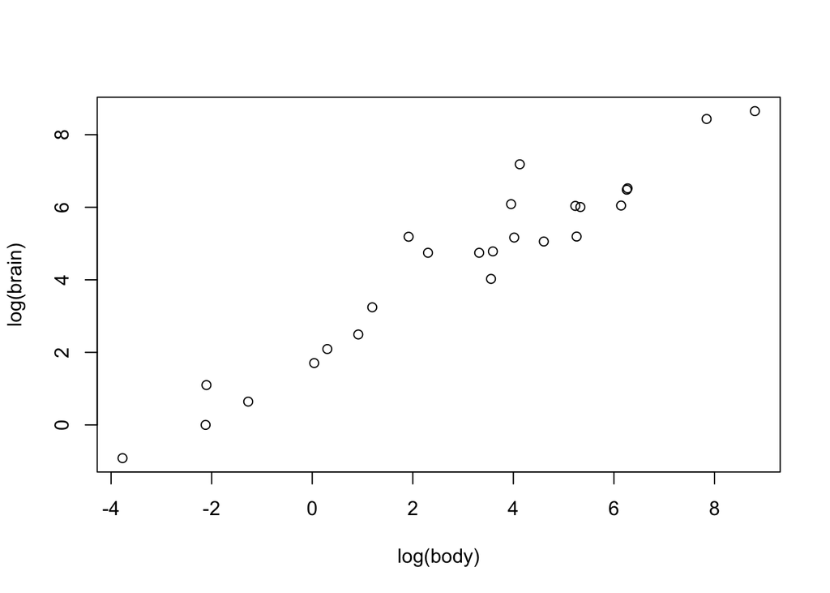

```r
which.out<-which( rownames(Animals) %in% c("Brachiosaurus", "Triceratops", "Dipliodocus"))
plot(log(brain)~log(body), Animals[-which.out,])
```

```r
cor(log(Animals[-which.out,]))
```

```
           body     brain
body  1.0000000 0.9600516
brain 0.9600516 1.0000000
```

Dal diagramma di dispersione senza le osservazioni anomale si vede che le variabili `log(body)` e `log(brain)` presentano una dipendenza lineare positiva (sono correlate positivamente), quantificata come molto forte dal coefficiente di correlazione lineare $r_{12}=0.96$ (Si noti che senza rimuovere le osservazioni anomale, $r_{12}=0.78$).